# PERFect filtering for mock data set 2

Ekaterina Smirnova

Fri Apr 13 09:33:02 2018

1. *Mock community data 2: bias experiment data*. These publicly available data (Brooks et al, 2015) were generated as a part of a study designed to evaluate the bias at each step of the VCU sequencing protocol, namely, DNA extraction, PCR amplification, sequencing and taxonomic classification. Mock community samples were created out of $7$ vaginally relevant bacteria by mixing prescribed quantities of cells, with quantities varying across samples according to an experimental design described in Brooks et al, 2015. As opposed to the positive controls data, bacteria appear in different proportions across samples. The number of taxa identified by the sequencing and bioinformatics pipeline was $46$.

## Results

1. Simultaneous PERFect with skew-normal distribution and NP ordering.
2. Simultaneous PERFect with skew-normal distribution and p-values ordering.

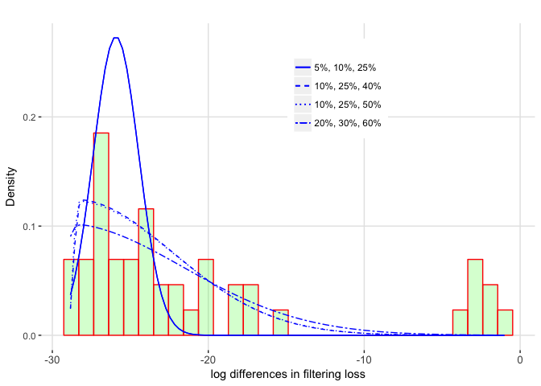

2. Permutation PERFect with skew-normal distribution NP ordering.

```
## Time difference of 32.14336 secs
```

```
## Time difference of 27.93579 secs
```

```
## Time difference of 24.83322 secs
```

```
## Time difference of 25.55581 secs
```

3. Permutation perfect with simultaneous p-values ordering from simultaneous PERFect with Skew Normal fit
4. Decontam package results
5. Traditional Filtering Rule 1
6. Traditional Filtering Rule 2

# Table of results comparison

1. Number of taxa present

|  | Total number of taxa | # of taxa preserved | Percentage of filtered taxa | # of true taxa | Percentage of contaminant taxa |
| --- | --- | --- | --- | --- | --- |
| PERFect_sim_a_0.15 | 46 | 26 | 43.48 | 7 | 48.72 |
| PERFect_sim_b_0.15 | 46 | 11 | 76.09 | 7 | 10.26 |
| PERFect_sim_c_0.15 | 46 | 11 | 76.09 | 7 | 10.26 |
| PERFect_sim_d_0.15 | 46 | 10 | 78.26 | 7 | 7.69 |
| PERFect_sim_a_0.10 | 46 | 22 | 52.17 | 7 | 38.46 |
| PERFect_sim_b_0.10 | 46 | 10 | 78.26 | 7 | 7.69 |
| PERFect_sim_c_0.10 | 46 | 10 | 78.26 | 7 | 7.69 |
| PERFect_sim_d_0.10 | 46 | 9 | 80.43 | 7 | 5.13 |
| PERFect_sim_a_0.05 | 46 | 22 | 52.17 | 7 | 38.46 |
| PERFect_sim_b_0.05 | 46 | 8 | 82.61 | 7 | 2.56 |
| PERFect_sim_c_0.05 | 46 | 8 | 82.61 | 7 | 2.56 |
| PERFect_sim_d_0.05 | 46 | 8 | 82.61 | 7 | 2.56 |
| PERFect_sim_a_pvals_0.15 | 46 | 24 | 47.83 | 7 | 43.59 |
| PERFect_sim_b_pvals_0.15 | 46 | 12 | 73.91 | 7 | 12.82 |
| PERFect_sim_c_pvals_0.15 | 46 | 12 | 73.91 | 7 | 12.82 |
| PERFect_sim_d_pvals_0.15 | 46 | 10 | 78.26 | 7 | 7.69 |
| PERFect_sim_a_pvals_0.10 | 46 | 24 | 47.83 | 7 | 43.59 |
| PERFect_sim_b_pvals_0.10 | 46 | 10 | 78.26 | 7 | 7.69 |
| PERFect_sim_c_pvals_0.10 | 46 | 10 | 78.26 | 7 | 7.69 |
| PERFect_sim_d_pvals_0.10 | 46 | 9 | 80.43 | 7 | 5.13 |
| PERFect_sim_a_pvals_0.05 | 46 | 18 | 60.87 | 7 | 28.21 |
| PERFect_sim_b_pvals_0.05 | 46 | 8 | 82.61 | 7 | 2.56 |
| PERFect_sim_c_pvals_0.05 | 46 | 8 | 82.61 | 7 | 2.56 |
| PERFect_sim_d_pvals_0.05 | 46 | 8 | 82.61 | 7 | 2.56 |
| PERFect_perm_np_a_0.15 | 46 | 12 | 73.91 | 7 | 12.82 |
| PERFect_perm_np_b_0.15 | 46 | 9 | 80.43 | 7 | 5.13 |
| PERFect_perm_np_c_0.15 | 46 | 9 | 80.43 | 7 | 5.13 |
| PERFect_perm_np_d_0.15 | 46 | 15 | 67.39 | 7 | 20.51 |
| PERFect_perm_np_a_0.10 | 46 | 11 | 76.09 | 7 | 10.26 |
| PERFect_perm_np_b_0.10 | 46 | 8 | 82.61 | 7 | 2.56 |
| PERFect_perm_np_c_0.10 | 46 | 8 | 82.61 | 7 | 2.56 |
| PERFect_perm_np_d_0.10 | 46 | 8 | 82.61 | 7 | 2.56 |
| PERFect_perm_np_a_0.05 | 46 | 10 | 78.26 | 7 | 7.69 |
| PERFect_perm_np_b_0.05 | 46 | 8 | 82.61 | 7 | 2.56 |
| PERFect_perm_np_c_0.05 | 46 | 8 | 82.61 | 7 | 2.56 |
| PERFect_perm_np_d_0.05 | 46 | 7 | 84.78 | 7 | 0.00 |
| PERFect_perm_pvals_a_0.15 | 46 | 12 | 73.91 | 7 | 12.82 |
| PERFect_perm_pvals_b_0.15 | 46 | 9 | 80.43 | 7 | 5.13 |
| PERFect_perm_pvals_c_0.15 | 46 | 9 | 80.43 | 7 | 5.13 |
| PERFect_perm_pvals_d_0.15 | 46 | 15 | 67.39 | 7 | 20.51 |
| PERFect_perm_pvals_a_0.10 | 46 | 12 | 73.91 | 7 | 12.82 |
| PERFect_perm_pvals_b_0.10 | 46 | 8 | 82.61 | 7 | 2.56 |
| PERFect_perm_pvals_c_0.10 | 46 | 8 | 82.61 | 7 | 2.56 |
| PERFect_perm_pvals_d_0.10 | 46 | 8 | 82.61 | 7 | 2.56 |
| PERFect_perm_pvals_a_0.05 | 46 | 10 | 78.26 | 7 | 7.69 |
| PERFect_perm_pvals_b_0.05 | 46 | 8 | 82.61 | 7 | 2.56 |
| PERFect_perm_pvals_c_0.05 | 46 | 8 | 82.61 | 7 | 2.56 |
| PERFect_perm_pvals_d_0.05 | 46 | 7 | 84.78 | 7 | 0.00 |
| Trad_R1 | 46 | 19 | 58.70 | 7 | 30.77 |
| Trad_R2 | 46 | 8 | 82.61 | 7 | 2.56 |

2. Running time for each method

| PERFect Simultaneous | PERFect Permutation | Traditional Rule 1 | Traditional Rule 2 |
| --- | --- | --- | --- |
| 1.0705 secs | 32.1434 secs | 0.0026 secs | 0.0086 secs |

# Comparison with other taxa orderings for supplementary materials

Simultaneous PERFect results with different orderings.

Permutation PERFect results with different orderings.

Comparison table for the paper

|  | Total number of taxa | # of taxa preserved | Percentage of filtered taxa | # of true taxa | Percentage of contaminant taxa |
| --- | --- | --- | --- | --- | --- |
| PERFect_sim_np | 46 | 10 | 78.26 | 7 | 7.69 |
| PERFect_sim_pvals | 46 | 10 | 78.26 | 7 | 7.69 |
| PERFect_sim_nc | 46 | 10 | 78.26 | 7 | 7.69 |
| PERFect_sim_ncw | 46 | 10 | 78.26 | 7 | 7.69 |
| PERFect_perm_np | 46 | 8 | 82.61 | 7 | 2.56 |
| PERFect_perm_pvals | 46 | 8 | 82.61 | 7 | 2.56 |
| PERFect_perm_nc | 46 | 8 | 82.61 | 7 | 2.56 |
| PERFect_perm_ncw | 46 | 8 | 82.61 | 7 | 2.56 |

```
## [1] 8
```

# True taxa ranking in each ordering

|  | Abundance (NP) | p-values | Number of connected taxa (NC) | Weighted number of connected taxa (NCw) |
| --- | --- | --- | --- | --- |
| Sneathia.amnii | 1 | 1 | 3 | 1 |
| Lactobacillus.iners | 2 | 2 | 1 | 2 |
| Streptococcus.agalactiae | 3 | 3 | 5 | 5 |
| Lactobacillus.crispatus_cluster | 4 | 4 | 2 | 3 |
| Atopobium.vaginae | 5 | 5 | 4 | 4 |
| Prevotella.bivia | 6 | 6 | 6 | 6 |
| Gardnerella.vaginalis | 7 | 7 | 7 | 7 |